# L14 - Webscrapping

Presenter: Olivia Beck  
Content credit: Matthew Beckman

# Chapter 16 (Data Scraping & Cleaning–Data Intake)

- There are a ton of ways to get data into R (often with dedicated packages)
  - CSV (comma-separated-values) is a really common format
    - Lots of software export to CSV
    - many functions to read CSV’s into R (e.g., we’ve seen `read_csv( )` from `readr` package)
    - `file.choose()` is handy to get file paths
  - R can handle lots of proprietary formats too (e.g., `foreign` package)
  - R can query relational databases like MS Access, Oracle, SAP, mySQL, etc (e.g, `rodbc` package)
  - Scraping web data

# Scraping Pole Vault Records from Wikipedia

Let’s say we want to scrape pole vault World Records from Wikipedia…

https://en.wikipedia.org/wiki/Men%27s_pole_vault_world_record_progression

# What’s a pole vault?

It’s an event in track and field competitions in which the athlete attempts the following (crudely speaking):

- Run as fast as possible while carrying a very long pole
- Jam the pole into a box in the ground
- Use the momentum to launch yourself as high as possible into the air
- Land safely on a huge cushion

Athletes repeat this as many times as they can while moving the crossbar up higher and higher.

#### It looks like this when it goes (extremely) well…

https://www.youtube.com/watch?v=OAVNb2N7ntM

#### …but sometimes turns out like this

https://www.youtube.com/watch?v=iN-rWSM0ZzM

# Scraping Pole Vault Records from Wikipedia

Let’s say we want to “scrape” pole vault world records from Wikipedia…

Here’s the webpage: https://en.wikipedia.org/wiki/Men%27s_pole_vault_world_record_progression

# Steps to scrape HTML data

1. Locate webpage
2. Identify data table(s) to scrape
3. Edit the R code chunk shown to paste `webpage` URL with quotes around it as shown.
4. Execute the code chunk to scrape all HTML tables found on the page into a “list” object in the R environment called `table_list` here

```
library("rvest")

webpage <- "page_url"

table_list <- webpage %>%
  read_html(header = TRUE) %>%
  html_nodes(css = "table") %>%
  html_table(fill = TRUE)

str(table_list)
```

# Scraping Pole Vault Records from Wikipedia

Using our handy template, we replace the `page_url`

```r
webpage <- "https://en.wikipedia.org/wiki/Men%27s_pole_vault_world_record_progression"

table_list <-
  webpage %>%
  read_html() %>%
  html_nodes(css = "table") %>%
  html_table(fill = TRUE)

str(table_list)  # This looks like a mess. We can look at this in our environment pannel
```

[output not shown]

[output cut: 30 more lines]

# Scraping Pole Vault Records from Wikipedia

Now we can use the data to answer lots of interesting questions

- RQ: Which nation has broken the record most frequently?
- RQ: Which athlete has broken the record most frequently?
- RQ: Which venue has seen the most record-breaking performances?

```r
# Look at the structure (look for how many tables are in the list; verify they are "data.frame" format)
str(table_list)
```

[output not shown]

[output cut: 30 more lines]

```r
# Inspect the second table in the list (IAAF Men from the Wikipedia Page)
PVrecords <- table_list[[2]]
head(PVrecords)
```

```
## # A tibble: 6 × 6
##   Mark                                         Athlete Nation Venue Date  `#[4]`
##   <chr>                                        <chr>   <chr>  <chr> <chr>  <int>
## 1 4.02 m (.mw-parser-output .frac{white-space… Marc W… Unite… Camb… June…      1
## 2 4.09 m (13 ft 5 in)                          Frank … Unite… Antw… Augu…      1
## 3 4.12 m (13 ft 6 in)                          Charle… Norway Cope… Sept…      1
## 4 4.21 m (13 ft 9+1⁄2 in)                      Charle… Norway Cope… July…      2
## 5 4.23 m (13 ft 10+1⁄2 in)                     Charle… Norway Oslo… Augu…      3
## 6 4.25 m (13 ft 11+1⁄4 in)                     Charle… Norway Turk… Sept…      4
```

# Pole Vault Records from Wikipedia

Maybe we plot the density of records?

- what would low density mean?
- what would high density mean?

```r
PVRecordsData <-
  PVrecords %>%
  mutate(Record_m = parse_number(Mark)) %>%
  select(Mark, Record_m)

head(PVRecordsData)
```

```
## # A tibble: 6 × 2
##   Mark                                                                  Record_m
##   <chr>                                                                    <dbl>
## 1 4.02 m (.mw-parser-output .frac{white-space:nowrap}.mw-parser-output…     4.02
## 2 4.09 m (13 ft 5 in)                                                       4.09
## 3 4.12 m (13 ft 6 in)                                                       4.12
## 4 4.21 m (13 ft 9+1⁄2 in)                                                   4.21
## 5 4.23 m (13 ft 10+1⁄2 in)                                                  4.23
## 6 4.25 m (13 ft 11+1⁄4 in)                                                  4.25
```

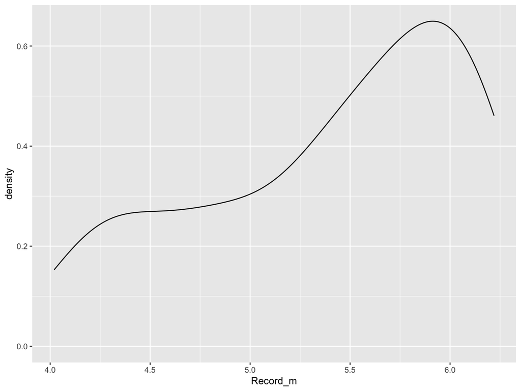

```r
PVRecordsData %>%
  ggplot(aes(x = Record_m)) +
  geom_density()
```

```r
round(PVRecordsData$Record_m) %>%
  table()
```

```
## .
##  4  5  6
## 11 26 41
```

# Penn State Football Receiving Statistics

1. Google Penn State Football Statistics
2. Edit the R code chunk shown to paste `webpage` URL with quotes around it as shown.
3. Execute the code chunk to scrape all HTML tables found on the page into a “list” object in the R environment called `Tables` here
4. Identify a data table from the source (for example, “receiving statistics”) and find it in the list object in your R environment

```
library("rvest")
page <- "http://www.espn.com/college-football/team/stats/_/id/213/penn-state-nittany-lions"

Tables <- page %>%
  read_html(header = TRUE) %>%
  html_nodes(css = "table") %>%
  html_table(fill = TRUE)
```

```
Tables[[1]]
```

# Penn State Football Receiving Statistics

```r
url <- "http://www.espn.com/college-football/team/stats/_/id/213/penn-state-nittany-lions"

PlayerStats <- url %>%
  read_html() %>%
  html_nodes(css = "table") %>%
  html_table(fill = TRUE)
```

```r
# R stores the result as a "list" object, so the double square brackets select an
#    element of the list, and we store it at as a data frame

ReceivingRaw <- PlayerStats[[6]]

# Inspect the Data Table
ReceivingRaw
```

```
## # A tibble: 21 × 5
##      REC YDS     AVG   LNG    TD
##    <int> <chr> <dbl> <int> <int>
##  1    46 611    13.3    58     2
##  2    51 577    11.3    34     5
##  3    24 389    16.2    88     4
##  4    32 362    11.3    67     5
##  5    20 328    16.4    48     4
##  6    19 273    14.4    48     1
##  7    20 188     9.4    45     1
##  8    10 123    12.3    38     3
##  9     8 89     11.1    20     0
## 10    11 85      7.7    22     1
## # ℹ 11 more rows
```

```r
# Add player names and remove totals
ReceivingStats <-
  bind_cols(PlayerStats[[5]], PlayerStats[[6]]) %>%
  filter(Name != "Total")

# Inspect FootballStatsClean
ReceivingStats
```

```
## # A tibble: 20 × 6
##    Name                       REC YDS     AVG   LNG    TD
##    <chr>                    <int> <chr> <dbl> <int> <int>
##  1 Parker Washington WR        46 611    13.3    58     2
##  2 Mitchell Tinsley WR         51 577    11.3    34     5
##  3 KeAndre Lambert-Smith WR    24 389    16.2    88     4
##  4 Brenton Strange TE          32 362    11.3    67     5
##  5 Theo Johnson TE             20 328    16.4    48     4
##  6 Harrison Wallace III WR     19 273    14.4    48     1
##  7 Kaytron Allen RB            20 188     9.4    45     1
##  8 Tyler Warren TE             10 123    12.3    38     3
##  9 Liam Clifford WR             8 89     11.1    20     0
## 10 Nicholas Singleton RB       11 85      7.7    22     1
## 11 Omari Evans WR               5 55     11      32     1
## 12 Khalil Dinkins TE            4 53     13.3    28     1
## 13 Devyn Ford RB                5 31      6.2    12     0
## 14 Sean Clifford QB             2 24     12      25     0
## 15 Keyvone Lee RB               3 23      7.7    10     1
## 16 Kaden Saunders WR            2 21     10.5    13     0
## 17 Malick Meiga WR              3 19      6.3     7     0
## 18 Tyler Holzworth RB           2 16      8       9     0
## 19 Jaden Dottin WR              2 14      7       9     0
## 20 Tank Smith RB                1 2       2       2     0
```

# Aside: XPath selector

- so far, we have been scraping every table in sight and then hunting through the results for the ones we want.
- you can scrape one specific table with an XPath selector
- some example code is below… basically you only need to change one line
  - use `html_node()` (singular) rather than `html_nodes()` (plural)
  - specify the XPath selector
  - see the help documentation for `html_nodes()` to learn more about the syntax
  - helpful instructions for getting the XPath to an element on a web page using Google Chrome browser: http://www.r-bloggers.com/using-rvest-to-scrape-an-html-table/
- CSS selectors for single table also available through the `selectr` package, which is a port of the python `cssselect` library (see help documentation for `html_nodes()`)

```
library("rvest")

page_url <- "https://en.wikipedia.org/wiki/Mile_run_world_record_progression"
XPATH <- '//*[@id="mw-content-text"]/div/table'

table_list <-
  page_url %>%
  read_html() %>%
  html_node(xpath = XPATH) %>%
  html_table(fill = TRUE)
```